# Tutorial 2.1: hypothesis testing on the armpit dataset

In this tutorial, we perform a hypothesis test on the “smelly armpit” dataset.

# 1 Smelly armpit dataset

Smelly armpits are not caused by sweat, itself. The smell is caused by specific micro-organisms belonging to the group of *Corynebacterium spp.* that metabolise sweat. Another group of abundant bacteria are the *Staphylococcus spp.*, these bacteria do not metabolise sweat in smelly compounds.

The CMET-groep at Ghent University does research to on transplanting the armpit microbiome to save people with smelly armpits.

- Proposed Therapy:
  1. Remove armpit-microbiome with antibiotics
  2. Influence armpit microbiome with microbial transplant (https://youtu.be/9RIFyqLXdVw)
- Experiment:
  - 20 subjects with smelly armpits are attributed to one of two treatment groups
  - placebo (only antibiotics)
  - transplant (antibiotica followed by microbial transplant).
  - The microbiome is sampled 6 weeks upon the treatment
  - The relative abundance of *Staphylococcus spp.* on *Corynebacterium spp.* + *Staphylococcus spp.* in the microbiome is measured via DGGE (*Denaturing Gradient Gel Electrophoresis*).

# 2 Goal

The overarching goal of this research was to assess if the relative abundance *Staphylococcus spp.* in the microbiome of the armpit is affected by transplanting the microbiome. To this end the researchers randomized patients to two treatment: A treatment with antibiotics only and a treatment with antibiotics and a microbial transplant.

In the tutorial on hypotheses testing we will use a formal statistical test to generalize the results from the sample to that of the population.

# 3 Import the dataset

```r
#Load the libraries
library(tidyverse)
```

Import the data

```r
ap <- read_csv("https://raw.githubusercontent.com/GTPB/PSLS20/master/data/armpit.csv")
glimpse(ap)
```

```
## Observations: 20
## Variables: 2
## $ trt <chr> "placebo", "placebo", "placebo", "placebo", "placebo", "pl...
## $ rel <dbl> 54.99208, 31.84466, 41.09948, 59.52064, 63.57341, 41.48649...
```

# 4 Data Exploration

A crucial first step in a data analysis is to visualize and to explore the raw data.

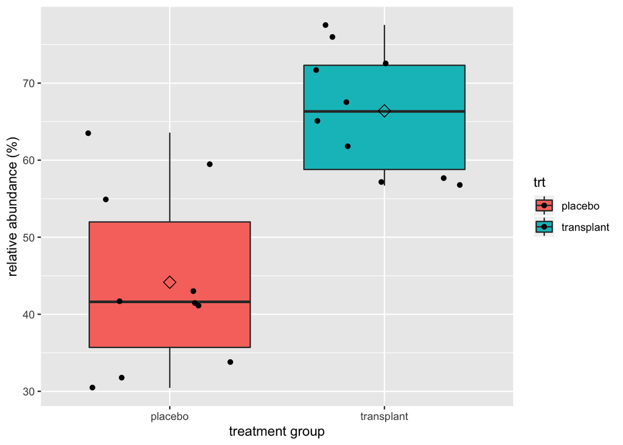

```r
ap %>% ggplot(aes(x=trt,y=rel,fill=trt)) +
  geom_boxplot(outlier.shape=NA) +
  geom_point(position="jitter") +
  ylab("relative abundance (%)") +
  xlab("treatment group") +
  stat_summary(fun.y=mean, geom="point", shape=5, size=3, color="black", fill="black")
```

We clearly see that, on average, the subjects who had a microbial transplant have a higher relative abundance of Staphylococcus spp. But is this difference statistically *significant* so that we can generalized what we observe in the sample to the population?

We can test this with an unpaired, two-sample t-test, which falsifies the null hypothesis that there is on average no difference in relative abundance of *Staphylococcus* in the armpit microbiome between the transplant and the placebo group against the alternative hypothesis that there is a difference in average abundance of *Staphyloccocus* in the armpit microbiome between the transplant and placebo treatment.

But, before we can start the analysis, we must check if all assumptions to perform a t-test are met.